# Neurotransmitter release and synaptic responses

2025

## Synaptic responses to neurotransmitter release

- Action potentials lead to neurotransmitter release across the synaptic cleft, binding to postsynaptic receptors and causing EPSPs or IPSPs.
- The PSP time course is often modeled as:

\[ \Delta V_{\text{PSP}}(t) = A t e^{-t/t_{\text{peak}}} \]

- \(A\): amplitude parameter
- \(t_{\text{peak}}\): time of maximum \(\Delta V\)
- This is often called the **alpha function**.

## Plotting the alpha function

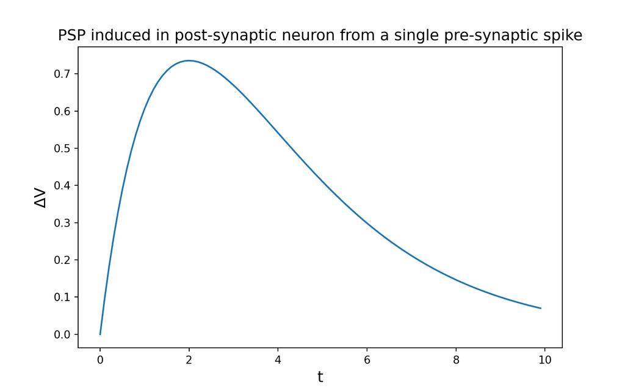

## Alpha function in a tiny network

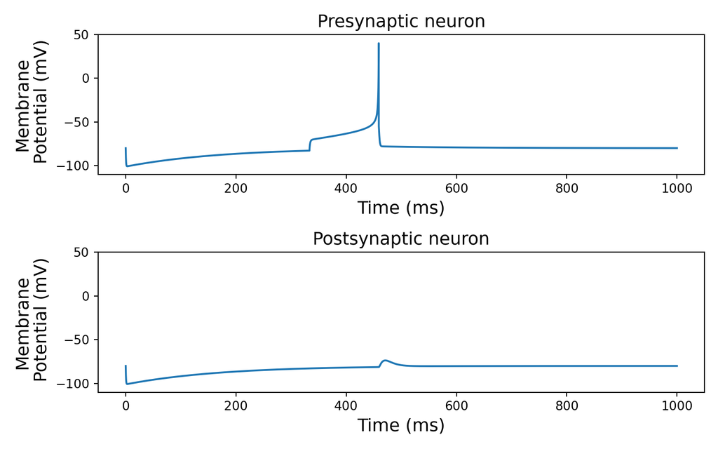

## PSPs superimpose

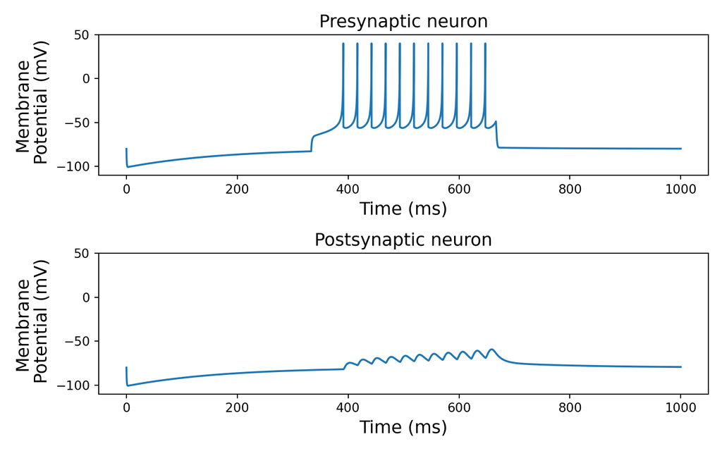

## PSPs as a change in conductance

- In conductance-based models like HH, PSPs are modeled as a change in conductance:

\[ \begin{align*} \frac{d}{dt}v(t) &= \left[ g(t)(v(t)-E) - g_{leak}(v(t) - E_{leak}) \right] / C \\ \frac{d}{dt}g(t) &= \left[ -g(t) + A_{psp} \delta(t_{spike}) \right]/ t_{peak} \end{align*} \]

- \(g(t)\): conductance
- \(A_{psp}\): spike amplitude
- \(t_{spike}\): spike time

## Conductance change and PSP from a single spike.

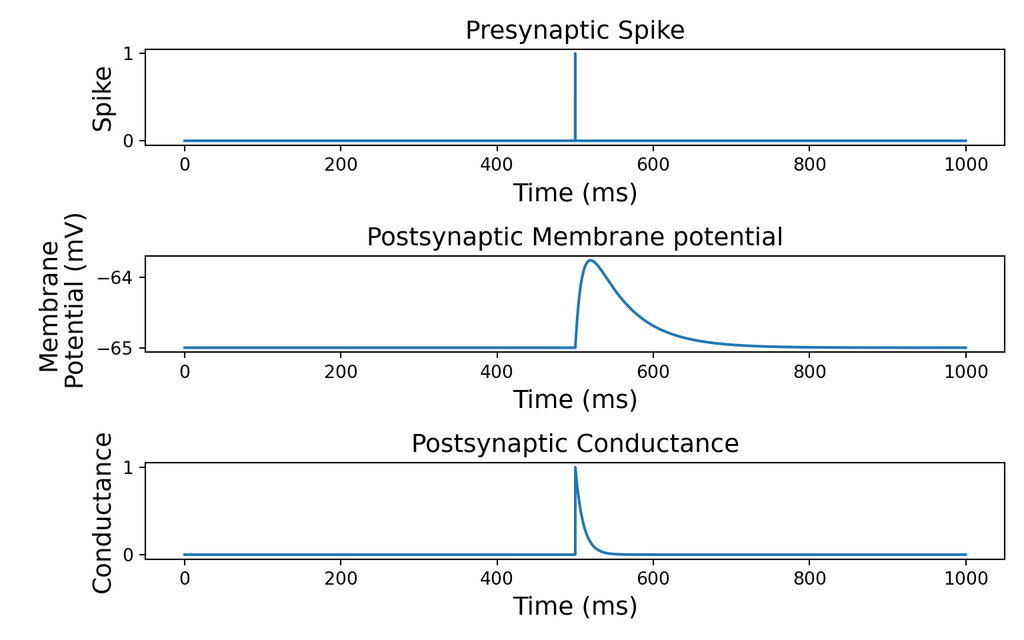

## Modelling PSPs in a simple neuron model

- We switch from thinking of \(g(t)\) as a conductance to thinking of it as the concentration of neurotransmitter released by the presynaptic neuron.
- Every neuron now tracks its own membrane potential \(v\), recovery variable \(u\), and neurotransmitter concentration \(g(t)\).
- If neuron **A** projects to neuron **B**, then neuron **A** will release neurotransmitter \(g_{\text{A}}(t)\) into the synaptic cleft, which will bind to receptors on neuron **B**, causing a change in its membrane potential \(v_{\text{B}}\).
- Presynaptic neurotransmitter release \(g_{\text{A}}(t)\) plays the role of external current in the equations for the postsynaptic neuron.

\[ \begin{align*} \frac{d}{dt} v_{\text{pre}} &= k(v_{\text{pre}} - v_{\text{rest}})(v - v_{\text{thresh}}) - u_{\text{pre}} + \mathbf{I_{\text{External}}} \\ \frac{d}{dt} u_{\text{pre}} &= a(bv_{\text{pre}} - u_{\text{pre}}) \\ \frac{d}{dt} g_{\text{pre}} &= \frac{-g_{\text{pre}} + A_{psp} \delta(t_{spike})}{t_{psp}} \\\\ \frac{d}{dt} v_{\text{post}} &= k(v_{\text{post}} - v_{\text{rest}})(v - v_{\text{thresh}}) - u_{\text{post}} + \mathbf{g_{\text{pre}}} \\ \frac{d}{dt} u_{\text{post}} &= a(bv_{\text{post}} - u_{\text{post}}) \\ \frac{d}{dt} g_{\text{post}} &= \frac{-g_{\text{post}} + A_{psp} \delta(t_{spike})}{t_{psp}} \\ \end{align*} \]

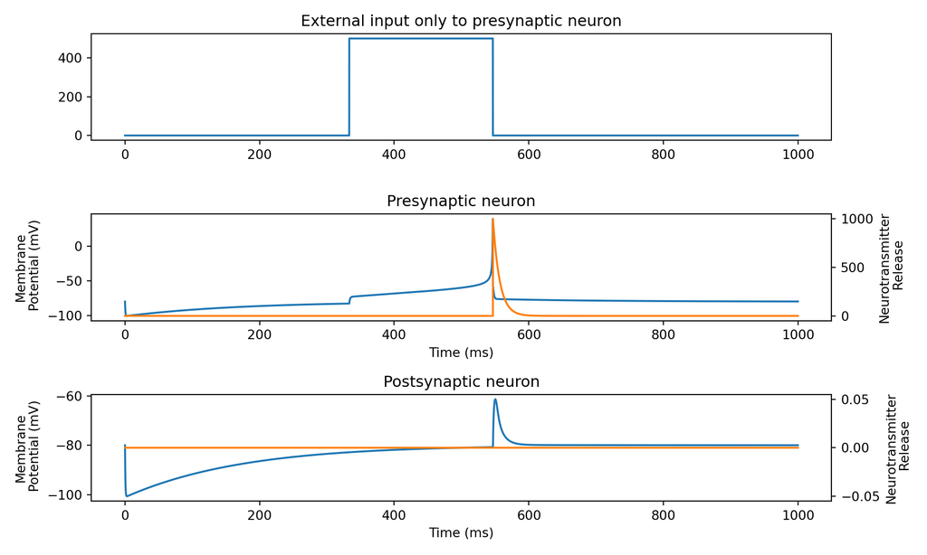

```python
# init stuff...
# ...

# begin simulation of simple network: I_external -> A -> B
for i in range(1, n):

    dvdt_A = (k * (v_A[i-1] - vr) * (v_A[i-1] - vt) - u_A[i-1] + I_ext[i-1]) / C
    dudt_A = a * (b * (v_A[i-1] - vr) - u_A[i-1])
    dgdt_A = (-g_A[i-1] + psp_amp * spike_A[i-1]) / psp_decay

    dvdt_B = (k * (v_B[i-1] - vr) * (v_B[i-1] - vt) - u_B[i-1] + w_AB * g_A[i-1]) / C
    dudt_B = a * (b * (v_B[i-1] - vr) - u_B[i-1])
    dgdt_B = (-g_B[i-1] + psp_amp * spike_B[i-1]) / psp_decay

    # Do state updates etc
    # ...
```